# 05 - Figure 3 Annotation Variants (p-value <-> asterisk) and Data-point Counts

# 1. CombinedPTCy.png (currently p-value text -> add asterisk version)

Data construction copied verbatim from `notebooks/02_clone_analysis.Rmd` (lines ~835-869).

```r
patient_data_allo <- dplyr::full_join(patient_data_all_2, meta_data,  by = "PatientID")
colnames(patient_data_allo) <- sapply(colnames(patient_data_allo), function(x){str_replace_all(x, "-", "")})
patient_data_allo <- patient_data_allo[patient_data_allo$Rep_div == "allo",]
patient_data_allo <- patient_data_allo[which(!is.na(patient_data_allo$timepoint)),]

patient_data_allo_copy <- patient_data_allo%>%
  mutate(timepoint = strtoi(timepoint))
patient_data_allo_copy <- patient_data_allo_copy[which(!is.na(patient_data_allo_copy$timepoint)),]
patient_data_allo_copy <- patient_data_allo_copy[which(!is.na(patient_data_allo_copy$shannons.diversity)),]
patient_data_allo_copy <- patient_data_allo_copy%>%
  mutate(GVHD_grade_14 = ifelse(GVHD_grade_14 == "Yes", 1, 0), GVHD_grade_24 = ifelse(GVHD_grade_24 == "Yes", 1, 0), GVHD_grade_34 = ifelse(GVHD_grade_34 == "Yes", 1, 0))%>%
  mutate(GVHD_GRADE = GVHD_grade_14 + GVHD_grade_24 + GVHD_grade_34)

data_CD48_all_expand_adj <- dplyr::full_join(data_CD48_all, clinical_data, by = 'PatientID')
data_CD48_all_expand_adj <- data_CD48_all_expand_adj[!is.na(data_CD48_all_expand_adj$cdr3_amino_acid),]

Both_results <- num_clone_fig(data_CD48_all, "PTCy", "PTCy vs No PTCy", num_cuts = 7, legend_title = "Treatment")
```

```
## [1]  14  22  28  56  90 138 180 365
```

```
## `summarise()` has regrouped the output.
## ℹ Summaries were computed grouped by bins and PTCy.
## ℹ Output is grouped by bins.
## ℹ Use `summarise(.groups = "drop_last")` to silence this message.
## ℹ Use `summarise(.by = c(bins, PTCy))` for per-operation grouping
##   (`?dplyr::dplyr_by`) instead.
```

```r
immdata_meta <- dplyr::full_join(Both_results[[4]], meta_data_clin, by = "PatientID")%>%
  mutate(PTCy = PTCy.x)%>%
  filter(!is.na(PTCy))

patient_data_allo_copy <- patient_data_allo_copy %>%
  filter(timepoint != 3)

if(remove_pat_regx != ""){
  data_CD48_all_expand_adj <- data_CD48_all_expand_adj[!grepl(remove_pat_regx,data_CD48_all_expand_adj$PatientID),]
  patient_data_allo_copy <- patient_data_allo_copy[!grepl(remove_pat_regx,patient_data_allo_copy$PatientID),]
}
```

# 1b. CombinedPTCy_365_consistent.png – apply the Figure-1C-style consistent filter to the PTCy comparison

`C_365_signif_hochberg.png` (the corrected Figure 1C) draws all three of its panels from one consistently filtered set: `timepoint > 3 & timepoint < 365 & cum_freq > 0` (cum. freq / Shannon panels) and `timepoint > 3 & timepoint < 365 & n > 0` (# of clones panel).

```r
patient_data_allo_365_ptcy <- patient_data_allo_copy[
  patient_data_allo_copy$timepoint < 365 &
  patient_data_allo_copy$timepoint > 3 &
  !is.na(patient_data_allo_copy$cum_freq) &
  patient_data_allo_copy$cum_freq > 0, ]

immdata_meta_365_ptcy <- immdata_meta[
  !is.na(immdata_meta$timepoint) &
  immdata_meta$timepoint < 365 &
  immdata_meta$timepoint > 3 &
  immdata_meta$n > 0, ]

cat("Panel 1 & 2 (cum_freq, Shannon entropy) -- patient_data_allo_365_ptcy\n")
```

```
## Panel 1 & 2 (cum_freq, Shannon entropy) -- patient_data_allo_365_ptcy
```

```r
cat("  total rows:", nrow(patient_data_allo_365_ptcy), "\n")
```

```
##   total rows: 105
```

```r
print(table(patient_data_allo_365_ptcy$PTCy))
```

```
##
## No PTCy    PTCy
##      53      52
```

```r
cat("\nPanel 3 (# of clones) -- immdata_meta_365_ptcy\n")
```

```
##
## Panel 3 (# of clones) -- immdata_meta_365_ptcy
```

```r
cat("  total rows:", nrow(immdata_meta_365_ptcy), "\n")
```

```
##   total rows: 105
```

```r
print(table(immdata_meta_365_ptcy$PTCy))
```

```
##
## No PTCy    PTCy
##      53      52
```

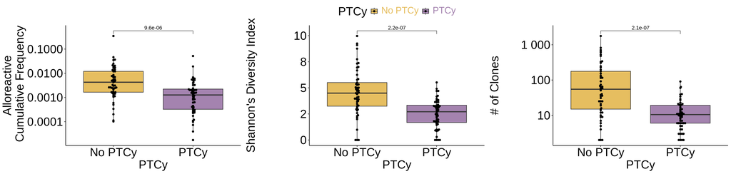

```r
cum_freq_plot_365 <- ggplot(patient_data_allo_365_ptcy, aes(x = PTCy, y = cum_freq, group = PTCy, fill = PTCy))+
  geom_boxplot()+
  stat_compare_means(comparisons = list(c("PTCy", "No PTCy")), method = "wilcox.test", label = "p.format", hide.ns = TRUE)+
  geom_beeswarm()+
  scale_y_continuous(trans = "log10", labels = scales::number_format(accuracy = 0.0001))+
  labs(y = "Alloreactive\n Cumulative Frequency")+
  theme_pubr()+
  theme(text = element_text(size = 24), legend.text = element_markdown(), legend.position = "none")+
    scale_fill_manual(values = c("#E6BE60", "#A483AF"),
                    labels = c(
      `No PTCy` = "<span style='color:#E6BE60;'>No PTCy</span>",
      PTCy = "<span style='color:#A483AF;'>PTCy</span>"))

shannons_plot_365 <- ggplot(patient_data_allo_365_ptcy, aes(x = PTCy, y = shannons.entropy, group = PTCy, fill = PTCy))+
  geom_boxplot()+
  stat_compare_means(comparisons = list(c("PTCy", "No PTCy")), method = "wilcox.test", label = "p.format", hide.ns = TRUE)+
  geom_beeswarm()+
  labs(y = "Shannon's Diversity Index")+
  scale_y_continuous(labels = scales::number_format(accuracy = 1))+
  theme_pubr()+
  theme(text = element_text(size = 24), legend.text = element_markdown())+
    scale_fill_manual(values = c("#E6BE60", "#A483AF"),
                    labels = c(
      `No PTCy` = "<span style='color:#E6BE60;'>No PTCy</span>",
      PTCy = "<span style='color:#A483AF;'>PTCy</span>"))

unique_clone_ptcy_plot_365 <- ggplot(immdata_meta_365_ptcy, aes(x = PTCy, y = n+1, group = PTCy, fill = PTCy))+
  geom_boxplot()+
  stat_compare_means(comparisons = list(c("PTCy", "No PTCy")), method = "wilcox.test", label = "p.format", hide.ns = TRUE)+
  geom_beeswarm()+
  scale_y_continuous(trans = "log10", labels = scales::number_format(accuracy = 1))+
  scale_x_discrete(na.translate = F)+
  theme_pubr()+
  theme(text = element_text(size = 24), legend.text = element_markdown(), legend.position = "none")+
  labs(y = "# of Clones")+
    scale_fill_manual(values = c("#E6BE60", "#A483AF"),
                    labels = c(
      `No PTCy` = "<span style='color:#E6BE60;'>No PTCy</span>",
      PTCy = "<span style='color:#A483AF;'>PTCy</span>"))

combined_plot_365 <- plot_grid(cum_freq_plot_365, shannons_plot_365, unique_clone_ptcy_plot_365, nrow = 1, align = "hv")
plot(combined_plot_365)
```

```r
ggsave(paste0(OUTPUT_PATH, '/Figure3/CombinedPTCy_365_consistent.png'), combined_plot_365, width = 21, height = 5, dpi = 600)
ggsave(paste0(OUTPUT_PATH, '/Figure3/CombinedPTCy_365_consistent.pdf'), combined_plot_365, width = 21, height = 5, dpi = 600)

tab_2f <- patient_data_allo_365_ptcy %>% group_by(PTCy) %>% summarise(N = n(), .groups = "drop")
make_sample_size_fig(tab_2f, "PTCy", "CombinedPTCy_365_consistent", ptcy_colors, "Figure3", "CombinedPTCy_365_consistent")
```

## Asterisk-annotation version of CombinedPTCy_365_consistent (only `label` changed: “p.format” -> “p.signif”)

Same `patient_data_allo_365_ptcy`/`immdata_meta_365_ptcy` (same consistent filter, same 105 patient-timepoints), same grouping/colors/theme – only the annotation style differs, so this is the asterisk counterpart of `CombinedPTCy_365_consistent.png` (p-value version kept above).

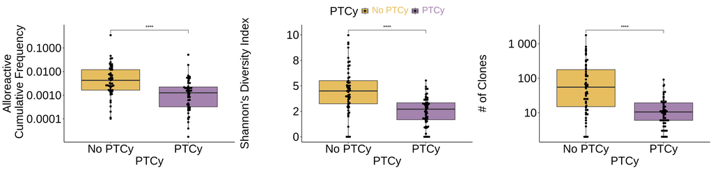

```r
cum_freq_plot_365_signif <- ggplot(patient_data_allo_365_ptcy, aes(x = PTCy, y = cum_freq, group = PTCy, fill = PTCy))+
  geom_boxplot()+
  stat_compare_means(comparisons = list(c("PTCy", "No PTCy")), method = "wilcox.test", label = "p.signif", hide.ns = TRUE)+
  geom_beeswarm()+
  scale_y_continuous(trans = "log10", labels = scales::number_format(accuracy = 0.0001))+
  labs(y = "Alloreactive\n Cumulative Frequency")+
  theme_pubr()+
  theme(text = element_text(size = 24), legend.text = element_markdown(), legend.position = "none")+
    scale_fill_manual(values = c("#E6BE60", "#A483AF"),
                    labels = c(
      `No PTCy` = "<span style='color:#E6BE60;'>No PTCy</span>",
      PTCy = "<span style='color:#A483AF;'>PTCy</span>"))

shannons_plot_365_signif <- ggplot(patient_data_allo_365_ptcy, aes(x = PTCy, y = shannons.entropy, group = PTCy, fill = PTCy))+
  geom_boxplot()+
  stat_compare_means(comparisons = list(c("PTCy", "No PTCy")), method = "wilcox.test", label = "p.signif", hide.ns = TRUE)+
  geom_beeswarm()+
  labs(y = "Shannon's Diversity Index")+
  scale_y_continuous(labels = scales::number_format(accuracy = 1))+
  theme_pubr()+
  theme(text = element_text(size = 24), legend.text = element_markdown())+
    scale_fill_manual(values = c("#E6BE60", "#A483AF"),
                    labels = c(
      `No PTCy` = "<span style='color:#E6BE60;'>No PTCy</span>",
      PTCy = "<span style='color:#A483AF;'>PTCy</span>"))

unique_clone_ptcy_plot_365_signif <- ggplot(immdata_meta_365_ptcy, aes(x = PTCy, y = n+1, group = PTCy, fill = PTCy))+
  geom_boxplot()+
  stat_compare_means(comparisons = list(c("PTCy", "No PTCy")), method = "wilcox.test", label = "p.signif", hide.ns = TRUE)+
  geom_beeswarm()+
  scale_y_continuous(trans = "log10", labels = scales::number_format(accuracy = 1))+
  scale_x_discrete(na.translate = F)+
  theme_pubr()+
  theme(text = element_text(size = 24), legend.text = element_markdown(), legend.position = "none")+
  labs(y = "# of Clones")+
    scale_fill_manual(values = c("#E6BE60", "#A483AF"),
                    labels = c(
      `No PTCy` = "<span style='color:#E6BE60;'>No PTCy</span>",
      PTCy = "<span style='color:#A483AF;'>PTCy</span>"))

combined_plot_365_signif <- plot_grid(cum_freq_plot_365_signif, shannons_plot_365_signif, unique_clone_ptcy_plot_365_signif, nrow = 1, align = "hv")
plot(combined_plot_365_signif)
```

```r
ggsave(paste0(OUTPUT_PATH, '/Figure3/CombinedPTCy_365_consistent_signif.png'), combined_plot_365_signif, width = 21, height = 5, dpi = 600)
ggsave(paste0(OUTPUT_PATH, '/Figure3/CombinedPTCy_365_consistent_signif.pdf'), combined_plot_365_signif, width = 21, height = 5, dpi = 600)

tab_2f_signif <- patient_data_allo_365_ptcy %>% group_by(PTCy) %>% summarise(N = n(), .groups = "drop")
make_sample_size_fig(tab_2f_signif, "PTCy", "CombinedPTCy_365_consistent_signif", ptcy_colors, "Figure3", "CombinedPTCy_365_consistent_signif")
```

# 2. all_All_byPTCy.png (currently asterisks -> add p-value version)

`count_clones`/`num_clones` copied verbatim from `notebooks/03_grade_ptcy_analysis.Rmd` (lines ~932-1045); `num_clones` already exposes a `pval_label` argument, so the p-value version only requires calling it with `pval_label = "p.adj.exact"` instead of the default `"p.adj.signif"`.

```r
count_clones <- function(data, type, metric = "cum_freq", num_cuts = 5, group_by = c("PatientID","timepoint", "PTCy")){
  data_proc <- data%>%
    group_by(across(all_of(c(group_by, type))))%>%
    dplyr::summarise(num_clones = sum(frequency), .groups = "keep")

  data_pre <- data_proc[grepl("MLR|unstim", data_proc$timepoint),]

  data_proc <- data_proc %>%
    mutate(timepoint = strtoi(timepoint))
  data_proc <- data_proc[!is.na(data_proc$timepoint),]

  data_post <- data_proc[data_proc$timepoint <= 365 & data_proc$timepoint > 3,] %>%
    subset(!is.na(timepoint))%>%
    ungroup()

  qs <- matrix(nrow = length(unique(data_post[[type]])), ncol = num_cuts+1)
  for(i in seq_along(unique(data_post[[type]]))){
    t <- unique(data_post[[type]])[[i]]
    qs[i,] <- quantile(data_post[data_post[[type]] == t,]$timepoint, probs = 0:num_cuts/num_cuts)
  }

  qs_breaks <- apply(qs,2, max)
  breaks <- unique(quantile(data_post$timepoint, probs = 0:num_cuts/num_cuts))

  data_post <- data_post%>%
    mutate(bins = cut(timepoint,breaks = breaks, include.lowest = TRUE))

  return(list(data_pre, data_post))
}

num_clones <- function(data, type, metric = "cum_freq", num_cuts = 5, title, ylab = "Allo Frequency", text_size = 20, group_by = c("PatientID", "timepoint", "PTCy"), pval_label = "p.adj.signif", pval_size = 8) {

  results <- count_clones(data, type, metric, num_cuts, group_by = group_by)
  data_post <- results[[2]]
  data_post$type_num <- as.numeric(factor(data_post[[type]]))

  data_post_n0 <- data_post %>%
    filter(num_clones != 0)

  wilcox_results <- compare_means(as.formula(paste0("num_clones ~ ", type)), data = data_post, group.by = "bins")

  stat_test <- data_post %>%
    group_by(bins) %>%
    pairwise_wilcox_test(as.formula(paste0("num_clones ~ ", type)), p.adjust.method = "hochberg") %>%
    add_xy_position(x = "bins") %>%
    mutate(
      p.adj = p.adjust(p, method = "hochberg"),
      p.adj.signif = symnum(
        p.adj,
        cutpoints = c(0, 0.0001, 0.001, 0.01, 0.05, 1),
        symbols = c("****", "***", "**", "*", "ns")
      ),
      p.adj.exact = ifelse(p.adj < 0.001, sprintf("p = %.2e", p.adj), sprintf("p = %.3f", p.adj))
    )

  box_plot_post <- ggboxplot(data_post, x = "bins", y = "num_clones", fill = type) +
    stat_pvalue_manual(stat_test, label = pval_label, tip.length = 0.01, step.increase = 0.00, bracket.nudge.y = -1, size = pval_size) +
    geom_beeswarm(data = data_post_n0, position = "dodge", dodge.width = .75, na.rm = TRUE, aes(x = bins, y = num_clones, group = .data[[type]])) +
    scale_y_continuous(trans = 'log10', labels = scales::number_format(accuracy = 0.0001)) +
    theme_pubr() +
    theme(
      text = element_text(size = text_size),
      axis.text.x = element_text(angle = 45, hjust = 1),
      panel.grid.major = element_blank(),
      panel.grid.minor = element_blank(),
      panel.background = element_blank(),
      axis.line = element_line(color = "black"),
      axis.ticks.length = unit(0.25, "cm"),
      legend.text = element_markdown()
    ) +
    labs(y = ylab, title = title, x = "Days")

  data_post <- data_post %>%
    mutate(timepoint = as.character(timepoint))
  data <- bind_rows(data_post)

  return(list(box_plot_post, wilcox_results, data))
}
```

Data construction copied verbatim from `notebooks/03_grade_ptcy_analysis.Rmd` (lines ~1051-1065):

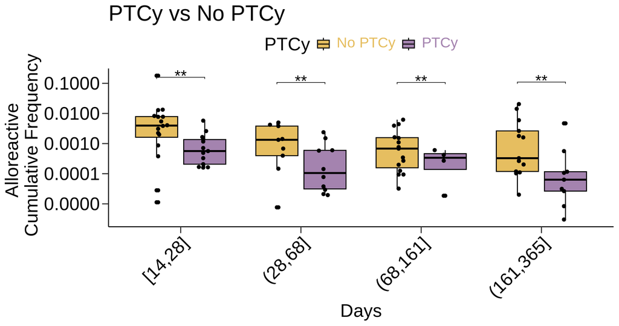

```r
data_CD48_all_expand_adj <- data_CD48_all_expand
data_CD48_all_expand_adj$cell_type <- gsub(" ", "",data_CD48_all_expand_adj$cell_type )
data_CD48_all_expand_adj <- dplyr::full_join(data_CD48_all_expand_adj, clinical_data, by = "PatientID")
data_CD48_all_expand_adj <- data_CD48_all_expand_adj%>%
  mutate(GVHD_GRADE_1 = ifelse(grepl("Severe", GVHD_GRADE_1), "Severe", GVHD_GRADE_1))

if(remove_pat_regx != ""){
  data_CD48_all_expand_adj <- data_CD48_all_expand_adj[!grepl(remove_pat_regx,data_CD48_all_expand_adj$PatientID),]
}

data_CD48_all_expand_adj <- data_CD48_all_expand_adj%>%
  mutate(GVHD_GRADE_1 = ifelse(grepl("No|Mild", GVHD_GRADE_1), "No/Mild", "Severe"))

result_All_byPTCy <- num_clones(data_CD48_all_expand_adj, "PTCy", num_cuts = 4, title = "PTCy vs No PTCy", ylab = "Alloreactive \n Cumulative Frequency", pval_label = "p.adj.signif", pval_size = 6)

All_byPTCy <- result_All_byPTCy[[1]]+
    scale_fill_manual(values = c("#E6BE60", "#A483AF"),
                    labels = c(
      `No PTCy` = "<span style='color:#E6BE60;'>No PTCy</span>",
      PTCy = "<span style='color:#A483AF;'>PTCy</span>"))

plot(All_byPTCy)
```

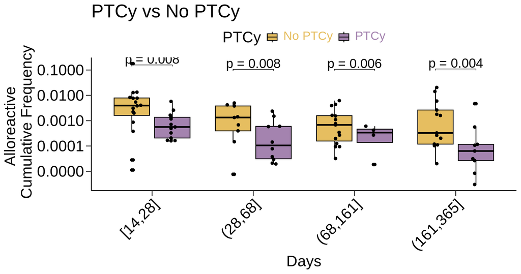

```r
ggsave(paste0(OUTPUT_PATH, '/Figure3/all_All_byPTCy.png'), All_byPTCy, width = 9.5, height = 5, dpi = 600)
ggsave(paste0(OUTPUT_PATH, '/Figure3/all_All_byPTCy.pdf'), All_byPTCy, width = 9.5, height = 5, dpi = 600)

tab_2g_sig <- result_All_byPTCy[[3]] %>% group_by(bins, PTCy) %>% summarise(N = n(), .groups = "drop") %>% rename(group = PTCy)
make_sample_size_fig(tab_2g_sig, "group", "all_All_byPTCy", ptcy_colors, "Figure3", "all_All_byPTCy", bins_col = "bins")

result_All_byPTCy_pvalue <- num_clones(data_CD48_all_expand_adj, "PTCy", num_cuts = 4, title = "PTCy vs No PTCy", ylab = "Alloreactive \n Cumulative Frequency", pval_label = "p.adj.exact", pval_size = 6)

All_byPTCy_pvalue <- result_All_byPTCy_pvalue[[1]]+
    scale_fill_manual(values = c("#E6BE60", "#A483AF"),
                    labels = c(
      `No PTCy` = "<span style='color:#E6BE60;'>No PTCy</span>",
      PTCy = "<span style='color:#A483AF;'>PTCy</span>"))

plot(All_byPTCy_pvalue)
```

```r
ggsave(paste0(OUTPUT_PATH, '/Figure3/all_All_byPTCy_pvalue.png'), All_byPTCy_pvalue, width = 9.5, height = 5, dpi = 600)
ggsave(paste0(OUTPUT_PATH, '/Figure3/all_All_byPTCy_pvalue.pdf'), All_byPTCy_pvalue, width = 9.5, height = 5, dpi = 600)

tab_2g <- result_All_byPTCy_pvalue[[3]] %>% group_by(bins, PTCy) %>% summarise(N = n(), .groups = "drop") %>% rename(group = PTCy)
make_sample_size_fig(tab_2g, "group", "all_All_byPTCy_pvalue", ptcy_colors, "Figure3", "all_All_byPTCy_pvalue", bins_col = "bins")
```